# Homework 7-1 Logistic Regression

#### Cross validation

Q14 (15pts): Carry out a logistic regression analysis using 5-fold cross-validation. Fit model2 for each fold and calculate the misclassificaton rate as well as the AUC. These evaluation results are stored in vectors which are consolidated in a data frame after the loop has finished. At the end, you have five values for misclassification rate and AUC. Use 0.5 as the classification threshold.

```r
set.seed(12345)

data.size = nrow(levee.df)
data.cols = ncol(levee.df)
num.folds = 5

levee.df["fold"] = floor(runif(data.size)*num.folds)+1
levee.df$fold = factor(levee.df$fold)
misclassification.rates = c()
auc = c()
class.threshold = 0.5
for(i in c(1:num.folds)){

    train = levee.df[(levee.df$fold!=i), 1:(data.cols)]
    test = levee.df[(levee.df$fold==i),1:(data.cols)]
    model.predictions = predict(model2, newdata = test[,-1], type="response")
    true.labels = test[,1]
    pred.labels = rep("No",length(true.labels))
    pred.labels[model.predictions>class.threshold]="Yes"
    pred.labels = factor(pred.labels)
    num.incorrect.labels = sum(pred.labels!=true.labels)
    misc.rate = num.incorrect.labels/length(pred.labels)

    misclassification.rates = c(misclassification.rates, misc.rate)
    pred = prediction(model.predictions,true.labels)

    perf.auc = performance(pred,'auc',fpr.stop=1)
    auc = c(auc, slot(perf.auc,"y.values")[[1]])
}
```

Q15 (5pts): Plot the misclassification results in a scatterplot, adding lines to connect the points. Title the plot: “Misclassification rates”, title the vertical axis: “misc”, and the horizontal axis: “folds”.

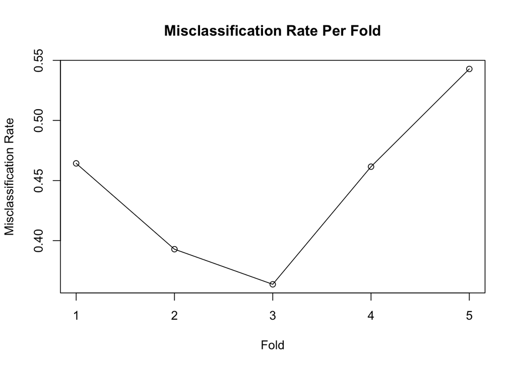

```r
plot(misclassification.rates, type = "o", xlab="Fold", ylab="Misclassification Rate", main = "Misclassification Rate Per Fold")
```

Q16 (5pts): Plot the AUC results in a scatterplot, adding lines to connect the points. Title the plot: “Area under ROC curve”, title the vertical axis: “auc”, and the horizontal axis: “folds”.

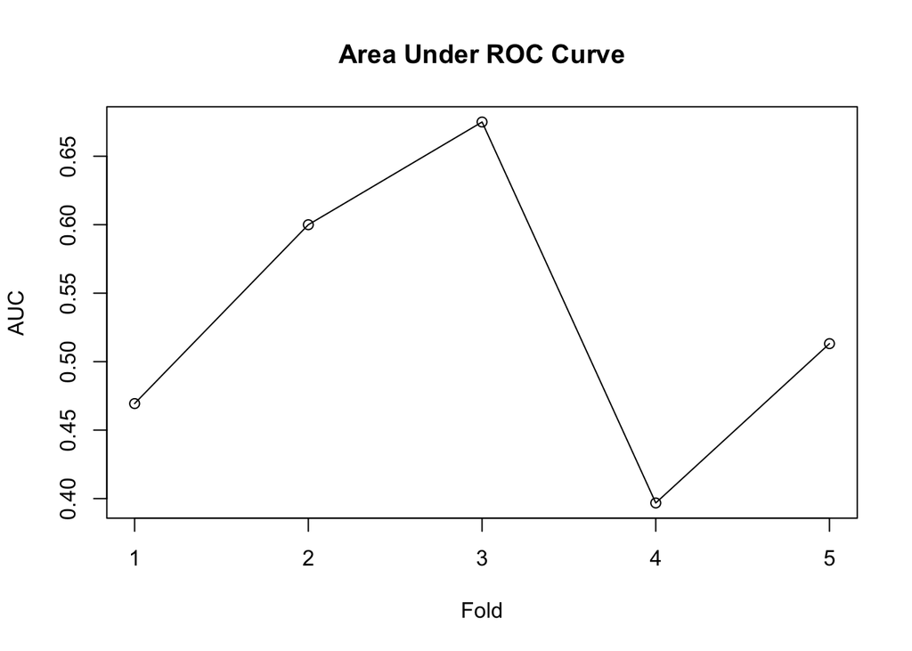

```r
plot(auc, type = "o", xlab="Fold", ylab="AUC", main = "Area Under ROC Curve")
```

Q17 (5pts): Briefly summarize the results of your cross validation. Suggest one ot two ways we might improve the results.

[output not shown]